# two-stage

## Two-stage model creation and testing narrative

I load in my data and set the Day as a factor.

```r
library(cvTools)
library(dplyr)
library(tidyr)
library(lme4)
library(spgwr)
library(leaps)
library(sp)
library(GWmodel)
Data <- read.csv(file = "C:\\Users\\aboser\\Documents\\GitHub\\PM_prediction\\Data\\Final_DFs\\Train.csv")

#make day factor for random effects
Data$Day <- as.factor(Data$Day)
```

```r
#make sure time constant values are really constant
check_time_constant <- function(column){
  Ids <- unique(Data[,"Id"])
  Bools <- c()
  for (i in Ids){
   Bools <-  c(Bools, length(unique(filter(Data, Id == i)[,column])) == 1)
  }
  unique(Bools)
}

check_time_constant("Elevation")
```

```
## [1] TRUE
```

```r
check_time_constant("Emissions")
```

```
## [1] TRUE
```

```r
check_time_constant("Forest")
```

```
## [1] TRUE
```

```r
check_time_constant("Roads")
```

```
## [1] TRUE
```

```r
check_time_constant("Streets")
```

```
## [1] TRUE
```

###some data exploration

How are the different parameters correlated?

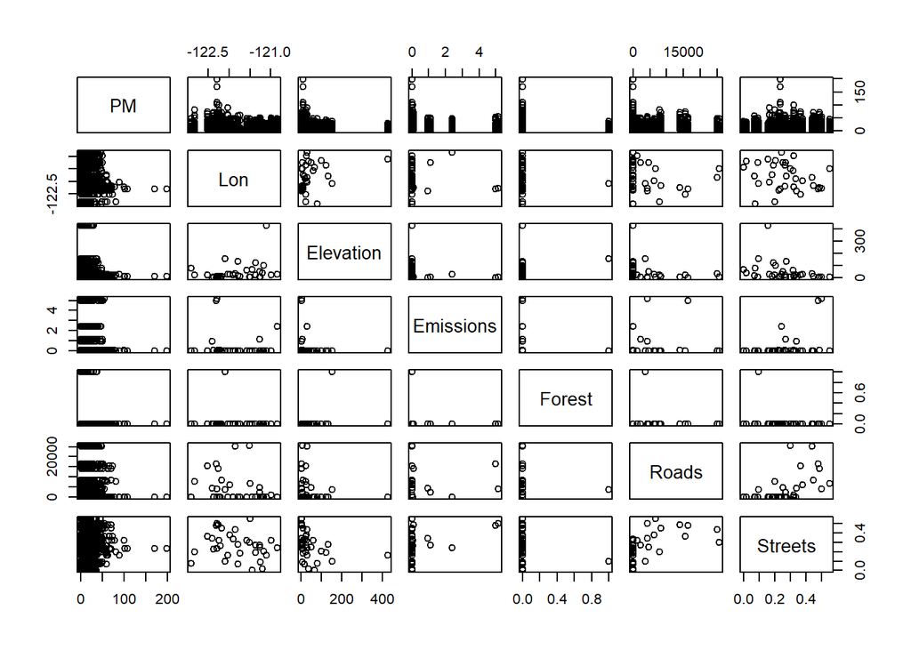

```r
pairs(PM ~ . ,
      data = cbind("PM" = Data$PM, Data[,5:10]))
```

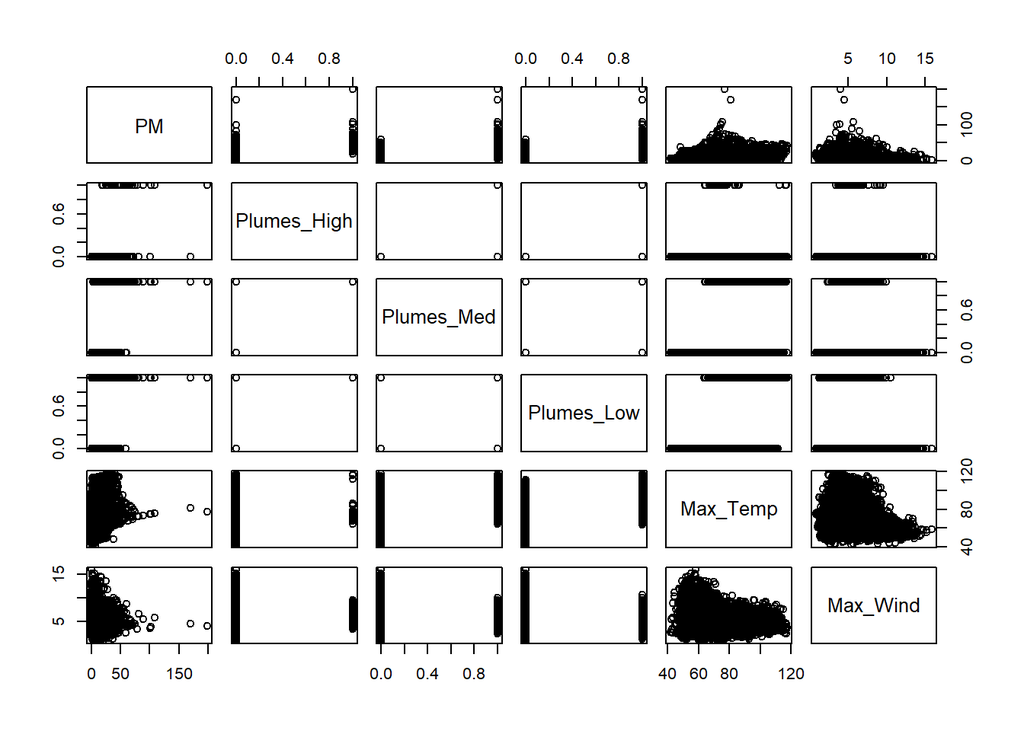

```r
pairs(PM ~ . ,
      data =  cbind("PM" = Data$PM, Data[,11:15]))
```

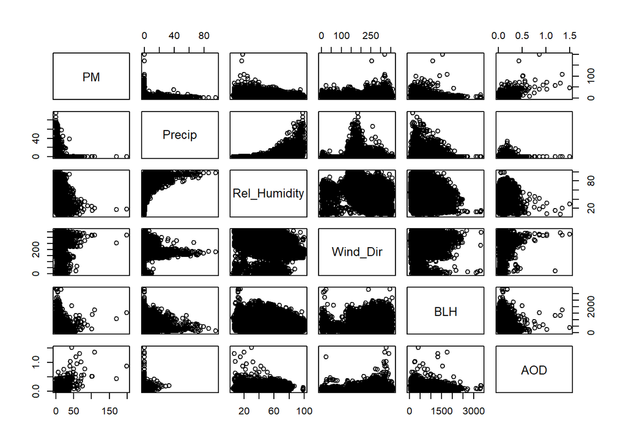

```r
pairs(PM ~ . ,
      data =  cbind("PM" = Data$PM, Data[,16:ncol(Data)]))
```

Might be easier to see with a correlation matrix:

```r
cor(Data[,5:ncol(Data)], use = "complete.obs")
```

```
##                       Lon   Elevation     Emissions       Forest        Roads
## Lon           1.000000000  0.32538808 -1.129135e-01 -0.096302615 -0.332511936
## Elevation     0.325388076  1.00000000 -1.803225e-01  0.244122628 -0.214495757
## Emissions    -0.112913457 -0.18032248  1.000000e+00 -0.065279109  0.189310709
## Forest       -0.096302615  0.24412263 -6.527911e-02  1.000000000 -0.014446025
## Roads        -0.332511936 -0.21449576  1.893107e-01 -0.014446025  1.000000000
## Streets      -0.286169735 -0.34049526  3.822122e-01 -0.236771992  0.569240710
## Plumes_High  -0.064548655 -0.02812315  6.172794e-04 -0.013546579  0.014276723
## Plumes_Med   -0.031565045 -0.01164404  9.437911e-04 -0.022009424 -0.005695463
## Plumes_Low    0.046157198  0.01735895 -1.537475e-02 -0.010827713 -0.022298017
## Max_Temp      0.385416302  0.05865925 -1.339879e-01 -0.036607298 -0.149371900
## Max_Wind     -0.190741533 -0.09119359 -1.797227e-02  0.063280808  0.069038284
## Precip       -0.007967762 -0.01712007 -1.672633e-05 -0.010024277  0.002714845
## Rel_Humidity -0.447455421 -0.12037453  1.814349e-01 -0.004905683  0.189206663
## Wind_Dir      0.009778064 -0.04537141  1.719877e-02  0.065499716  0.004693264
## BLH           0.237132085  0.04408365 -9.160275e-02 -0.083613134 -0.116804295
## AOD          -0.096548677 -0.08025638  5.952878e-02 -0.029716398  0.023461872
## PM           -0.079282141 -0.14279867  6.909543e-02 -0.081935628  0.026622089
##                   Streets   Plumes_High    Plumes_Med  Plumes_Low     Max_Temp
## Lon          -0.286169735 -0.0645486551 -0.0315650451  0.04615720  0.385416302
## Elevation    -0.340495263 -0.0281231537 -0.0116440391  0.01735895  0.058659250
## Emissions     0.382212208  0.0006172794  0.0009437911 -0.01537475 -0.133987881
## Forest       -0.236771992 -0.0135465785 -0.0220094242 -0.01082771 -0.036607298
## Roads         0.569240710  0.0142767225 -0.0056954629 -0.02229802 -0.149371900
## Streets       1.000000000  0.0065982724 -0.0172298819 -0.03792698 -0.179905690
## Plumes_High   0.006598272  1.0000000000  0.4175972226  0.16657626 -0.001197019
## Plumes_Med   -0.017229882  0.4175972226  1.0000000000  0.38212359  0.154739082
## Plumes_Low   -0.037926976  0.1665762639  0.3821235867  1.00000000  0.379433989
## Max_Temp     -0.179905690 -0.0011970186  0.1547390823  0.37943399  1.000000000
## Max_Wind      0.015826665  0.0008380967 -0.0389540845 -0.04150314 -0.077753463
## Precip        0.005470837 -0.0120774152 -0.0265754633 -0.07141038 -0.217574315
## Rel_Humidity  0.232084626 -0.0620783997 -0.1714910796 -0.36425595 -0.845366639
## Wind_Dir     -0.051582370  0.0367421629 -0.0131392151 -0.02433483  0.060659517
## BLH          -0.132519148  0.0169472806 -0.0216903955 -0.16600380 -0.226764254
## AOD           0.020825779  0.3688412149  0.3971249039  0.37629239  0.141327285
## PM            0.070985547  0.4265530028  0.4657533504  0.38930977  0.188842925
##                   Max_Wind        Precip Rel_Humidity     Wind_Dir         BLH
## Lon          -0.1907415334 -7.967762e-03 -0.447455421  0.009778064  0.23713209
## Elevation    -0.0911935881 -1.712007e-02 -0.120374527 -0.045371415  0.04408365
## Emissions    -0.0179722701 -1.672633e-05  0.181434862  0.017198771 -0.09160275
```

[output cut: 17 more lines]

```
## Emissions     0.059528783  0.06909543
## Forest       -0.029716398 -0.08193563
## Roads         0.023461872  0.02662209
## Streets       0.020825779  0.07098555
## Plumes_High   0.368841215  0.42655300
## Plumes_Med    0.397124904  0.46575335
## Plumes_Low    0.376292391  0.38930977
## Max_Temp      0.141327285  0.18884293
## Max_Wind      0.069162961 -0.09803209
## Precip        0.070771831 -0.09169354
## Rel_Humidity -0.036854830 -0.23234261
## Wind_Dir     -0.004181562 -0.03971629
## BLH          -0.110599480 -0.17567671
## AOD           1.000000000  0.44588272
## PM            0.445882723  1.00000000
```

It’s cool to see that the Plumes are looking good :) also AOD looks good. The lags in precipitation don’t look like they’re doing any good. (I also checked one day after just out of curiosity and that wasn’t any good.)

I don’t bother to check on normality because it doesn’t actually matter if the distributions are normal if I don’t care about the error bars. The linear model will maximize for any linear relationship regardless of distribution. However, linearity is important. From the above plots, it looks like doing a log transformation on PM might actially help with prediction.

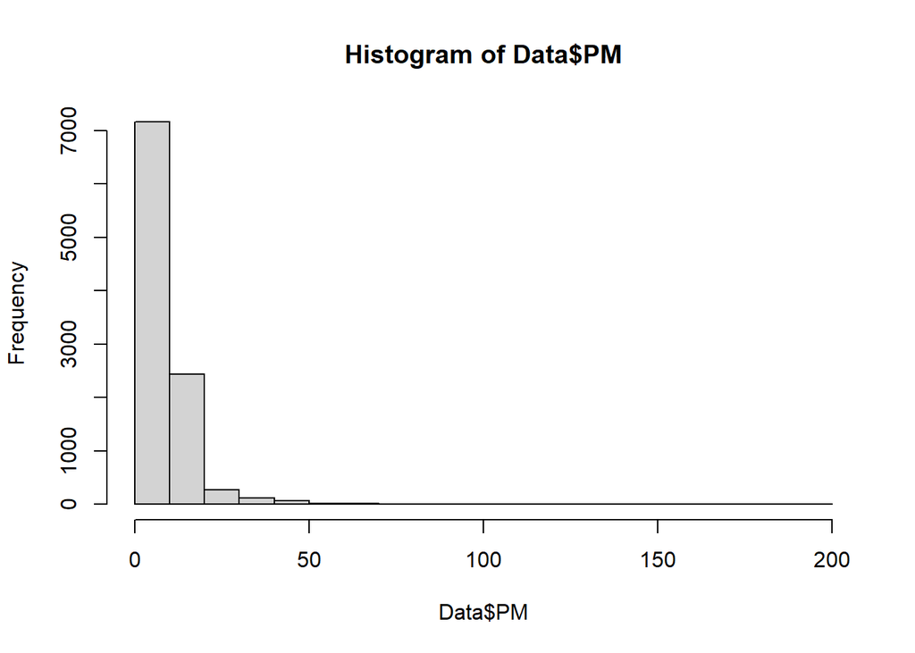

```r
Data$log_PM <- log(Data$PM)
hist(Data$PM)
```

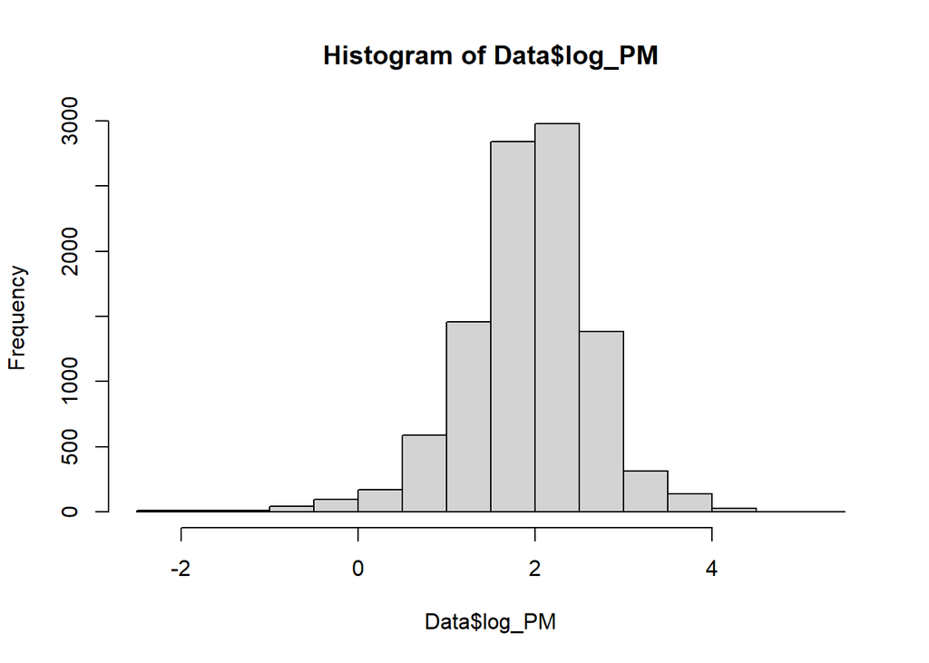

```r
hist(Data$log_PM)
```

It certainly makes PM look more normal

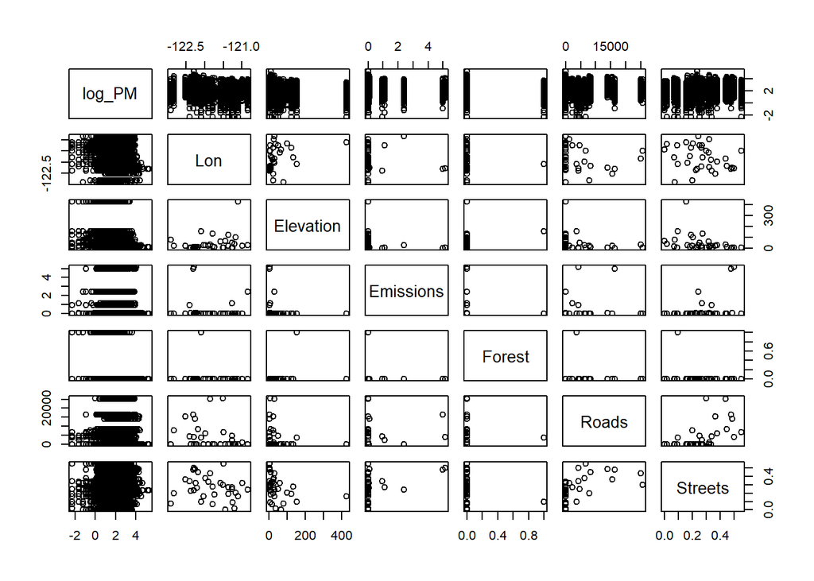

```r
pairs(log_PM ~ . ,
      data = cbind("log_PM" = Data$log_PM, Data[,5:10]))
```

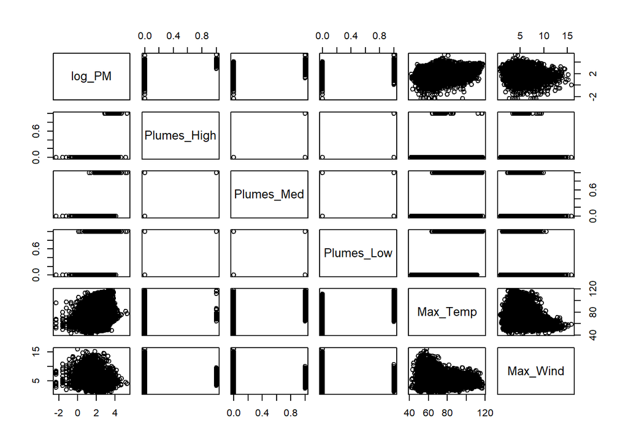

```r
pairs(log_PM ~ . ,
      data =  cbind("log_PM" = Data$log_PM, Data[,11:15]))
```

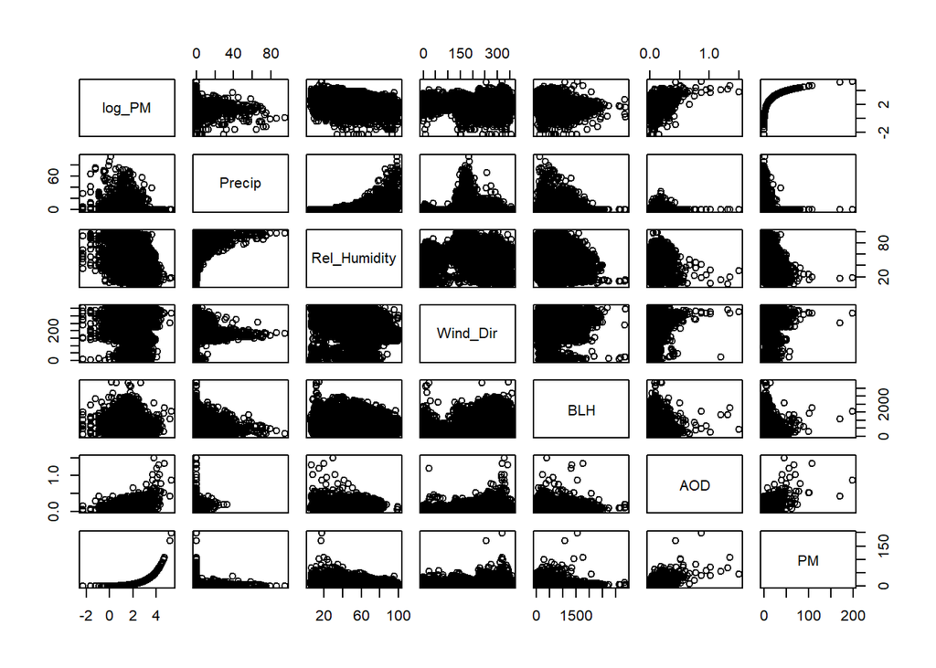

```r
pairs(log_PM ~ . ,
      data =  cbind("log_PM" = Data$log_PM, Data[,16:ncol(Data)]))
```

Before adding the mixed effects, I just fit a linear model without the day specific random effects to see which parameters seem most pertinent.

```r
lm_model <- lm(formula = PM ~ Elevation +
                                 Emissions +
                                 Forest +
                                 Roads +
                                 Streets +
                                 Plumes_High +
                                 Plumes_Med +
                                 Plumes_Low +
                                 Max_Temp +
                                 Max_Wind +
                                 Precip +
                                 Rel_Humidity +
                                 Wind_Dir +
                                 BLH +
                                 AOD,
               data = Data)
summary(lm_model)
```

```
##
## Call:
## lm(formula = PM ~ Elevation + Emissions + Forest + Roads + Streets +
##     Plumes_High + Plumes_Med + Plumes_Low + Max_Temp + Max_Wind +
##     Precip + Rel_Humidity + Wind_Dir + BLH + AOD, data = Data)
##
## Residuals:
##     Min      1Q  Median      3Q     Max
## -30.626  -3.007  -0.344   2.381 141.731
##
## Coefficients:
##                Estimate Std. Error t value Pr(>|t|)
## (Intercept)   2.577e+01  1.170e+00  22.036  < 2e-16 ***
## Elevation    -1.179e-02  1.014e-03 -11.625  < 2e-16 ***
## Emissions     2.290e-01  6.197e-02   3.696 0.000221 ***
## Forest       -1.998e+00  4.545e-01  -4.397 1.12e-05 ***
## Roads        -1.498e-05  1.383e-05  -1.083 0.278787
## Streets       1.683e+00  7.386e-01   2.279 0.022713 *
## Plumes_High   2.128e+01  1.116e+00  19.059  < 2e-16 ***
## Plumes_Med    8.961e+00  4.971e-01  18.027  < 2e-16 ***
## Plumes_Low    2.569e+00  2.342e-01  10.971  < 2e-16 ***
## Max_Temp     -1.270e-01  1.011e-02 -12.557  < 2e-16 ***
## Max_Wind     -2.977e-01  4.613e-02  -6.454 1.17e-10 ***
## Precip       -1.399e-01  5.061e-02  -2.764 0.005732 **
## Rel_Humidity -1.428e-01  8.092e-03 -17.642  < 2e-16 ***
## Wind_Dir     -2.955e-03  1.062e-03  -2.783 0.005408 **
## BLH          -2.556e-03  1.834e-04 -13.937  < 2e-16 ***
## AOD           2.078e+01  1.008e+00  20.615  < 2e-16 ***
## ---
## Signif. codes:  0 '***' 0.001 '**' 0.01 '*' 0.05 '.' 0.1 ' ' 1
##
## Residual standard error: 5.768 on 6285 degrees of freedom
##   (3781 observations deleted due to missingness)
## Multiple R-squared:  0.4364, Adjusted R-squared:  0.435
## F-statistic: 324.4 on 15 and 6285 DF,  p-value: < 2.2e-16
```

It looks like Roads/streets, precipitation and wind direction seem to be the least important, but these confidence intervals can’t be trusted due to correlation between parameters.

I compare this to a model fitting log(PM)

```r
lm_model <- lm(formula = log_PM ~ Elevation +
                                 Emissions +
                                 Forest +
                                 Roads +
                                 Streets +
                                 Plumes_High +
                                 Plumes_Med +
                                 Plumes_Low +
                                 Max_Temp +
                                 Max_Wind +
                                 Precip +
                                 Rel_Humidity +
                                 Wind_Dir +
                                 BLH +
                                 AOD,
               data = Data)
summary(lm_model)
```

```
##
## Call:
## lm(formula = log_PM ~ Elevation + Emissions + Forest + Roads +
##     Streets + Plumes_High + Plumes_Med + Plumes_Low + Max_Temp +
##     Max_Wind + Precip + Rel_Humidity + Wind_Dir + BLH + AOD,
##     data = Data)
##
## Residuals:
##     Min      1Q  Median      3Q     Max
## -4.2758 -0.2852  0.0655  0.3623  2.0959
##
## Coefficients:
##                Estimate Std. Error t value Pr(>|t|)
## (Intercept)   2.994e+00  1.136e-01  26.367  < 2e-16 ***
## Elevation    -1.756e-03  9.843e-05 -17.838  < 2e-16 ***
## Emissions     2.887e-02  6.017e-03   4.799 1.63e-06 ***
## Forest       -2.627e-01  4.413e-02  -5.954 2.76e-09 ***
## Roads         2.146e-06  1.343e-06   1.598    0.110
## Streets       9.828e-02  7.171e-02   1.371    0.171
## Plumes_High   6.339e-01  1.084e-01   5.848 5.22e-09 ***
## Plumes_Med    3.854e-01  4.826e-02   7.986 1.64e-15 ***
## Plumes_Low    2.995e-01  2.274e-02  13.174  < 2e-16 ***
## Max_Temp     -3.919e-03  9.817e-04  -3.992 6.64e-05 ***
## Max_Wind     -2.479e-02  4.478e-03  -5.536 3.21e-08 ***
## Precip       -2.229e-02  4.914e-03  -4.537 5.82e-06 ***
## Rel_Humidity -9.199e-03  7.856e-04 -11.709  < 2e-16 ***
## Wind_Dir     -4.256e-04  1.031e-04  -4.127 3.72e-05 ***
## BLH          -3.165e-04  1.781e-05 -17.771  < 2e-16 ***
## AOD           9.310e-01  9.788e-02   9.512  < 2e-16 ***
## ---
## Signif. codes:  0 '***' 0.001 '**' 0.01 '*' 0.05 '.' 0.1 ' ' 1
##
## Residual standard error: 0.5601 on 6285 degrees of freedom
##   (3781 observations deleted due to missingness)
## Multiple R-squared:  0.3163, Adjusted R-squared:  0.3146
## F-statistic: 193.8 on 15 and 6285 DF,  p-value: < 2.2e-16
```

Weirdly, it’s way worse. I go back to just PM.

###Choosing which variables to include

```r
reg <- leaps::regsubsets(PM ~ Elevation +
                                 Emissions +
                                 Forest +
                                 Roads +
                                 Streets +
                                 Plumes_High +
                                 Plumes_Med +
                                 Plumes_Low +
                                 Max_Temp +
                                 Max_Wind +
                                 Precip +
                                 Rel_Humidity +
                                 Wind_Dir +
                                 BLH +
                                 AOD,
                         data = Data,
                         method = "exhaustive",
                         nbest = 10,
                         nvmax = 30)
reg_summary <-  summary(reg)

bestbic <- order(reg_summary$bic, decreasing = FALSE)[1:5]

getvars <- function(id){
  vars <- names(coef(reg, id))[-1]
}

lapply(bestbic, getvars)
```

```
## [[1]]
##  [1] "Elevation"    "Emissions"    "Forest"       "Plumes_High"  "Plumes_Med"
##  [6] "Plumes_Low"   "Max_Temp"     "Max_Wind"     "Rel_Humidity" "BLH"
## [11] "AOD"
##
## [[2]]
##  [1] "Elevation"    "Emissions"    "Forest"       "Plumes_High"  "Plumes_Med"
##  [6] "Plumes_Low"   "Max_Temp"     "Max_Wind"     "Rel_Humidity" "Wind_Dir"
## [11] "BLH"          "AOD"
##
## [[3]]
##  [1] "Elevation"    "Emissions"    "Forest"       "Plumes_High"  "Plumes_Med"
##  [6] "Plumes_Low"   "Max_Temp"     "Max_Wind"     "Precip"       "Rel_Humidity"
## [11] "BLH"          "AOD"
##
## [[4]]
##  [1] "Elevation"    "Emissions"    "Forest"       "Plumes_High"  "Plumes_Med"
##  [6] "Plumes_Low"   "Max_Temp"     "Max_Wind"     "Precip"       "Rel_Humidity"
## [11] "Wind_Dir"     "BLH"          "AOD"
##
## [[5]]
##  [1] "Elevation"    "Emissions"    "Forest"       "Streets"      "Plumes_High"
##  [6] "Plumes_Med"   "Plumes_Low"   "Max_Temp"     "Max_Wind"     "Rel_Humidity"
## [11] "BLH"          "AOD"
```

Using BIC, it looks like the best model leaves out Roads and Streets, Precipitation, and Wind direction. This is mostly consistent with the statistical significance of the coefficients above.

I begin by creating a mixed effects model. My equation is:
$$PM_{2.5, st} = (b_0 + b_{0,t}) + (b_1 + b_{1,t})AOD_{st} + (b_2 + b_{2,t})BLH_{st} + \\
(b_3 + b_{3,t})WindDirection_{st} + (b_4 + b_{4,t})RelativeHumidity_{st} + \\
(b_5 + b_{5,t})Precipitation(Lag)_{st} + (b_6 + b_{6,t})WindSpeed_{st} + \\
(b_7 + b_{7,t})MaximumTemperature_{st} + (b_8 + b_{8,t})LowPlumes_{st} + \\
(b_9 + b_{9,t})MediumPlumes_{st} + (b_{10} + b_{10,t})HighPlumes_{st} + \\
b_{11}Streets_s + b_{12}MajorRoads_s + b_{13}ForestCover_s + \\
b_{14}Emissions_s + b_{15}Elevation_s + \epsilon_{st}(b_{0,t}b_{1,t}b_{2,t}) \tilde{} N[(0,0,0), \Phi)$$

Given that there are many missing AOD and BLH values, I separate the data into data with and without AOD/BLH and train models on both.

```r
w_AOD <- filter(Data, !is.na(AOD), !is.na(BLH))
wo_AOD <- filter(Data, is.na(AOD), !is.na(BLH))
wo_AOD_wo_BLH <- filter(Data, is.na(AOD), is.na(BLH))
```

```r
#function to get R2 from an LME
get_r2 <- function(formula, Data){
  model <- lmer(formula,
                    data = Data)

  r2 <- 1 - (sum((predict(model) - Data$PM)^2)/sum((Data$PM - mean(Data$PM))^2))
  return(list("model" = model, "r2" = r2))
}
```

```r
full_formula <-  "PM ~ Elevation +
                      Emissions +
                      Forest +
                      Roads +
                      Streets +
                      Plumes_High +
                      Plumes_Med +
                      Plumes_Low +
                      Max_Temp +
                      Max_Wind +
                      Precip +
                      Rel_Humidity +
                      Wind_Dir +
                      BLH +
                      AOD +
                      (1 +
                         Plumes_High +
                      Plumes_Med +
                      Plumes_Low +
                      Max_Temp +
                      Max_Wind +
                      Precip +
                      Rel_Humidity +
                      Wind_Dir +
                      BLH +
                      AOD| Day)"

# Unadjusted Rs value for lme
tmp <- get_r2(full_formula, w_AOD)
```

```
## boundary (singular) fit: see ?isSingular
```

```r
full_model <- tmp$model
tmp$r2
```

```
## [1] 0.7781917
```

```r
reduced_formula <- "PM ~ Elevation +
                      Emissions +
                      Forest +
                      Streets +
                      Plumes_High +
                      Plumes_Med +
                      Plumes_Low +
                      Max_Temp +
                      Max_Wind +
                      Rel_Humidity +
                      BLH +
                      AOD +
                      (1 +
                         Plumes_High +
                      Plumes_Med +
                      Plumes_Low +
                      Max_Temp +
                      Max_Wind +
                      Rel_Humidity +
                      BLH +
                      AOD| Day)"

get_r2(reduced_formula, w_AOD)$r2
```

```
## boundary (singular) fit: see ?isSingular
```

```
## [1] 0.7729707
```

```r
reduced_formula_no_AOD <- "PM ~ Elevation +
                      Emissions +
                      Forest +
                      Streets +
                      Plumes_High +
                      Plumes_Med +
                      Plumes_Low +
                      Max_Temp +
                      Max_Wind +
                      Rel_Humidity +
                      BLH +
                      (1 +
                         Plumes_High +
                      Plumes_Med +
                      Plumes_Low +
                      Max_Temp +
                      Max_Wind +
                      Rel_Humidity +
                      BLH| Day)"

get_r2(reduced_formula_no_AOD, filter(Data, !is.na(BLH)))$r2
```

```
## boundary (singular) fit: see ?isSingular
```

```
## [1] 0.7615107
```

```r
get_r2(reduced_formula_no_AOD, w_AOD)$r2
```

```
## boundary (singular) fit: see ?isSingular
```

```
## [1] 0.7415276
```

```r
get_r2(reduced_formula_no_AOD, wo_AOD)$r2
```

```
## boundary (singular) fit: see ?isSingular
```

```
## [1] 0.8166489
```

Interestingly, the data that has no AOD performs best.

###Cross validation It is important to note that due to missing values sometimes I cannot test on the full test subset.

```r
R2 <- function(prediction, true){
  (sum(
    (prediction - mean(prediction))
    *(true - mean(true))
    )/
      (sqrt(
        sum(
          (prediction - mean(prediction)
          )^2))*
         sqrt(
           sum(
             ((true - mean(true))^2)))
       ))^2
}

CV <- function(k, Data, formula){

Folds <- cvFolds(length(unique(Data$Id)),k)
folds <- Folds$which
names(folds) <- Folds$subsets[,1]

# make folds based on location Id
stations <- as.character(as.numeric(as.factor(Data$Id)))
station_folds <- folds[stations]

Es <- list()
test_PM <- list()
tp <- list()
fold_df <- as.data.frame(matrix(data = NA, nrow = k + 1, ncol = 7))
names(fold_df) <- c("stations", "MAE", "MSE", "RMSE", "NSE", "Bias", "R2")

for(i in unique(station_folds)){

  train_D <- Data[station_folds != i,]

  lme_model <- lmer(formula = formula,
                 data = train_D)

  test_D <- Data[station_folds == i & Data$Day %in% unique(train_D$Day),]
  # test_D <- Data[station_folds == i & Data$Day,] #some days are not trained on.

  test_predictions <- predict(lme_model, newdata = test_D)

  test_stations <- unique(test_D$Id)
  fold_df$stations[i] <- list(test_stations)

  E <- (test_D$PM - test_predictions)
  fold_df$Bias[i] <- mean(E)
  fold_df$MAE[i] <- mean(abs(E))
  fold_df$MSE[i] <- mean(E^2)
  fold_df$RMSE[i] <- sqrt(mean(E^2))
  fold_df$NSE[i] <- 1 - ((mean(E^2))/var(test_D$PM))
  fold_df$R2[i] <- R2(test_predictions, test_D$PM)

  test_PM[[i]] <- test_D$PM
  Es[[i]] <- E
  tp[[i]] <- test_predictions

  # paste0("Fold ", i," has MSE ", mean(E^2), ". The stations that are in this fold are: station " , test_stations , ".")

}
fold_df$stations[k+1] <- "All"

fold_df$Bias[k+1] <- mean(unlist(Es))
fold_df$MAE[k+1] <- mean(abs(unlist(Es)))
fold_df$MSE[k+1] <- mean(unlist(Es)^2)
fold_df$RMSE[k+1] <- sqrt(mean(unlist(Es)^2))
fold_df$NSE[k+1] <- 1 - (mean(unlist(Es)^2)/var(unlist(test_PM)))
fold_df$R2[k+1] <- R2(unlist(tp), unlist(test_PM))

# paste0("CV MSE: ", MSE, ". R2: ", R2, ". RMSE: ", RMSE, ". MAE: ", MAE, ".")

return(fold_df)
}

start_time <- Sys.time()
leave_one_out <- CV(34, w_AOD, full_formula)
```

[output not shown]

```
## fixed-effect model matrix is rank deficient so dropping 1 column / coefficient
```

```
## boundary (singular) fit: see ?isSingular
```

```r
leave_one_out$stations <- leave_one_out$stations %>% unlist() %>% as.numeric()
write.csv(leave_one_out, file = "C:\\Users\\aboser\\Documents\\GitHub\\PM_prediction\\Data\\Final_DFs\\LME_CV.csv", row.names = FALSE)
end_time <- Sys.time()

end_time - start_time
```

```
## Time difference of 1.060667 hours
```

```r
leave_one_out
```

```
##    stations      MAE        MSE      RMSE         NSE       Bias        R2
## 1      1131 3.044886  15.427233  3.927752  0.17388599 -2.7104554 0.6118021
## 2      4853 3.241603  19.254829  4.388032  0.09972434 -2.0369920 0.3610962
## 3      5361 4.013034  23.658653  4.864016  0.35430141 -3.3878589 0.6685748
## 4      6968 2.346221  11.881847  3.447006  0.30165155 -1.5427596 0.5639396
## 5     14069 4.502399  30.769212  5.547000  0.20388535  4.3494688 0.7269893
## 6     14301 2.080230  10.878770  3.298298  0.70827409  1.0558051 0.7838205
## 7     17814 2.100692  14.148934  3.761507  0.74481328 -0.6248908 0.7994756
## 8     18169 3.131780  24.079645  4.907101  0.62692885  0.5278891 0.6302671
## 9     22168 2.393501  13.960021  3.736311  0.66815836  0.8682381 0.6859165
## 10    23072 2.658759  10.289364  3.207704  0.51272517 -2.4536678 0.8170829
## 11    23278 1.630672   6.109285  2.471697  0.77271532  0.2734943 0.7749164
## 12    24661 1.603180   6.791079  2.605970  0.86781902 -0.3147914 0.8906350
## 13    25349 2.491274  26.040624  5.103001  0.40395455 -0.3729480 0.4712467
## 14    26069 2.412348   9.550665  3.090415  0.84277391  2.0472445 0.9316600
```

[output cut: 21 more lines]

```r
start_time <- Sys.time()
leave_one_out_red <- CV(34, w_AOD, reduced_formula)
```

[output not shown]

```
## fixed-effect model matrix is rank deficient so dropping 1 column / coefficient
```

```
## boundary (singular) fit: see ?isSingular
```

```r
leave_one_out_red$stations <- leave_one_out_red$stations %>% unlist() %>% as.numeric()
write.csv(leave_one_out_red, file = "C:\\Users\\aboser\\Documents\\GitHub\\PM_prediction\\Data\\Final_DFs\\LME_CV_red.csv", row.names = FALSE)
end_time <- Sys.time()

end_time - start_time
```

```
## Time difference of 22.97529 mins
```

```r
leave_one_out_red
```

```
##    stations      MAE        MSE      RMSE         NSE       Bias        R2
## 1      1131 3.153551  16.731123  4.090370  0.10406385 -2.7237885 0.5511917
## 2      4853 3.254028  19.417311  4.406508  0.09212736 -2.0233536 0.3603285
## 3      5361 3.960916  23.171920  4.813722  0.36758546 -3.2894303 0.6636752
## 4      6968 2.289029  10.667966  3.266185  0.37299667 -1.5721825 0.5869696
## 5     14069 2.659632  16.778991  4.096217  0.56586473  2.2740467 0.7405327
## 6     14301 2.106813  11.281294  3.358764  0.69747997  1.0313004 0.7624161
## 7     17814 2.088716  17.828448  4.222375  0.67845046 -0.5581679 0.7611382
## 8     18169 3.131708  23.337091  4.830848  0.63843339  0.4040034 0.6393759
## 9     22168 2.419583  14.537369  3.812790  0.65443430  0.9371384 0.6742310
## 10    23072 2.618643  10.072775  3.173764  0.52298223 -2.3747404 0.8024572
## 11    23278 1.611536   5.602492  2.366958  0.79156963  0.2858176 0.7973219
## 12    24661 1.533747   6.473037  2.544216  0.87400936 -0.1799644 0.8915973
## 13    25349 2.432447  23.859305  4.884599  0.45388291 -0.3705113 0.5072528
## 14    26069 2.463618  10.187572  3.191798  0.83228895  2.0691617 0.9267969
```

[output cut: 21 more lines]

The cross-validation is ok – a decent start.

idea: it would probably be good if I split the days into sunny and cloudy and chose which model to put them in based on that.

##Time for step two: the GWR!

```r
#This uses spgwr

start_time <- Sys.time()

w_AOD$resid <- predict(full_model) - w_AOD$PM
data.bw <- gwr.sel(resid ~ AOD, data = w_AOD, longlat = TRUE, coords = cbind(w_AOD$Lon, w_AOD$Lat))
```

```
## Bandwidth: 112.8966 CV score: 81993.7
## Bandwidth: 182.4882 CV score: 82343.91
## Bandwidth: 69.88666 CV score: 80870.78
## Bandwidth: 43.30504 CV score: 78584.07
## Bandwidth: 26.8767 CV score: 75149.94
## Bandwidth: 16.72343 CV score: 71924.85
## Bandwidth: 10.44836 CV score: 70314.46
## Bandwidth: 6.570157 CV score: 69200.11
## Bandwidth: 4.173295 CV score: 68258.88
## Bandwidth: 2.691952 CV score: 67963.68
## Bandwidth: 1.434619 CV score: 67964.98
## Bandwidth: 2.070355 CV score: 67946.88
## Bandwidth: 2.075003 CV score: 67946.86
## Bandwidth: 2.119372 CV score: 67946.74
## Bandwidth: 2.338078 CV score: 67948.79
## Bandwidth: 2.128881 CV score: 67946.74
## Bandwidth: 2.128469 CV score: 67946.74
## Bandwidth: 2.128415 CV score: 67946.74
## Bandwidth: 2.128375 CV score: 67946.74
## Bandwidth: 2.128415 CV score: 67946.74
```

```r
data.gauss <- gwr(resid ~ AOD, data = w_AOD, longlat = TRUE, bandwidth = data.bw, hatmatrix = TRUE, coords = cbind(w_AOD$Lon, w_AOD$Lat))
data.gauss
```

```
## Call:
## gwr(formula = resid ~ AOD, data = w_AOD, coords = cbind(w_AOD$Lon,
##     w_AOD$Lat), bandwidth = data.bw, hatmatrix = TRUE, longlat = TRUE)
## Kernel function: gwr.Gauss
## Fixed bandwidth: 2.128415
## Summary of GWR coefficient estimates at data points:
##                   Min.   1st Qu.    Median   3rd Qu.      Max. Global
## X.Intercept.  -2.89950  -1.33832  -0.13501   1.16641   2.98955      0
## AOD          -17.42611  -2.69019  -0.73048   4.34336  21.17760      0
## Number of data points: 6301
## Effective number of parameters (residual: 2traceS - traceS'S): 65.93655
## Effective degrees of freedom (residual: 2traceS - traceS'S): 6235.063
## Sigma (residual: 2traceS - traceS'S): 3.212713
## Effective number of parameters (model: traceS): 64.71896
## Effective degrees of freedom (model: traceS): 6236.281
## Sigma (model: traceS): 3.212399
## Sigma (ML): 3.195859
## AICc (GWR p. 61, eq 2.33; p. 96, eq. 4.21): 32656.02
## AIC (GWR p. 96, eq. 4.22): 32587.89
## Residual sum of squares: 64355.35
## Quasi-global R2: 0.2180446
```

```r
end_time <- Sys.time()

end_time - start_time
```

```
## Time difference of 1.141231 hours
```

cross-validation

```r
#using spgwr
CV <- function(k, Data, formula){

  #First create the folds
Folds <- cvFolds(length(unique(Data$Id)),k)
folds <- Folds$which
names(folds) <- Folds$subsets[,1]

# make folds based on location Id
stations <- as.character(as.numeric(as.factor(Data$Id)))
station_folds <- folds[stations]

#parameters I want to save after each fold
Es <- list()
test_PM <- list()
tp <- list()
fold_df <- as.data.frame(matrix(data = NA, nrow = k + 1, ncol = 7))
names(fold_df) <- c("stations", "MAE", "MSE", "RMSE", "NSE", "Bias", "R2")

#loop through the folds and fit/test the full model each time.
for(i in unique(station_folds)){
  # The way the two-stage model is broken down:
  # 1: use the training data to fit a linear mixed effects model
  # 2: using the test data, predict the PM using the LME and calculate the residuals
  # 3: use the training data to fit the GWR model on the residuals (actual - predicted) from the LME model
  # 4: use the test data to predict the residuals from the LME model
  # 5: subtract the gwr-predicted residuals from the lme-predicted PM values to obtain the final prediction.

  train_D <- Data[station_folds != i,]
  test_D <- Data[station_folds == i & Data$Day %in% unique(train_D$Day),]
  # test_D <- Data[station_folds == i & Data$Day,] #some days are not trained on.

  # 1:
  lme_model <- lmer(formula = formula,
                 data = train_D)

  # 2:
  lme_predictions <- predict(lme_model, newdata = test_D)
  train_D$resid <- train_D$PM - lme_predictions

  # 3 and 4:

  #convert train and test data to sp for easier use in spgwr
  train_sp <- SpatialPointsDataFrame(coords = cbind(train_D$Lon, train_D$Lat), data = train_D, proj4string = CRS("+proj=longlat +datum=WGS84 +ellps=WGS84 +towgs84=0,0,0"))
  test_sp <- SpatialPointsDataFrame(coords = cbind(test_D$Lon, test_D$Lat), data = test_D, proj4string = CRS("+proj=longlat +datum=WGS84 +ellps=WGS84 +towgs84=0,0,0"))

  gwr.bw <- gwr.sel(resid ~ AOD, data = train_sp, longlat = TRUE)
  gwr_model <- gwr(resid ~ AOD, data = train_sp, bandwidth = gwr.bw, longlat = TRUE, fit.points = test_sp, predictions = TRUE)
  gwr_resid <- gwr_model$SDF$pred

  test_predictions <- lme_predictions - gwr_resid

  test_stations <- unique(test_D$Id)
  fold_df$stations[i] <- list(test_stations)

  E <- (test_D$PM - test_predictions)
  fold_df$Bias[i] <- mean(E)
  fold_df$MAE[i] <- mean(abs(E))
  fold_df$MSE[i] <- mean(E^2)
  fold_df$RMSE[i] <- sqrt(mean(E^2))
  fold_df$NSE[i] <- 1 - ((mean(E^2))/var(test_D$PM))
  fold_df$R2[i] <- R2(test_predictions, test_D$PM)

  test_PM[[i]] <- test_D$PM
  Es[[i]] <- E
  tp[[i]] <- test_predictions

  # paste0("Fold ", i," has MSE ", mean(E^2), ". The stations that are in this fold are: station " , test_stations , ".")

}
fold_df$stations[k+1] <- "All"

fold_df$Bias[k+1] <- mean(unlist(Es))
fold_df$MAE[k+1] <- mean(abs(unlist(Es)))
fold_df$MSE[k+1] <- mean(unlist(Es)^2)
fold_df$RMSE[k+1] <- sqrt(mean(unlist(Es)^2))
fold_df$NSE[k+1] <- 1 - (mean(unlist(Es)^2)/var(unlist(test_PM)))
fold_df$R2[k+1] <- R2(unlist(tp), unlist(test_PM))

# paste0("CV MSE: ", MSE, ". R2: ", R2, ". RMSE: ", RMSE, ". MAE: ", MAE, ".")

return(fold_df)
}

start_time <- Sys.time()
leave_one_out <- CV(34, w_AOD, full_formula)
```

```
## boundary (singular) fit: see ?isSingular
```

```
## Bandwidth: 108.1005 CV score: 401987.6
## Bandwidth: 174.7357 CV score: 403824.3
## Bandwidth: 66.91772 CV score: 398088.6
## Bandwidth: 41.46535 CV score: 392133.9
## Bandwidth: 25.73492 CV score: 383592.6
## Bandwidth: 16.01298 CV score: 378932.6
## Bandwidth: 10.00449 CV score: 380749
## Bandwidth: 16.05066 CV score: 378931.6
## Bandwidth: 16.30822 CV score: 378929.7
## Bandwidth: 19.9089 CV score: 379772
## Bandwidth: 16.24431 CV score: 378929.4
## Bandwidth: 16.24388 CV score: 378929.4
## Bandwidth: 16.24405 CV score: 378929.4
## Bandwidth: 16.24401 CV score: 378929.4
## Bandwidth: 16.24409 CV score: 378929.4
## Bandwidth: 16.24405 CV score: 378929.4
```

```
## boundary (singular) fit: see ?isSingular
```

```
## Bandwidth: 112.8966 CV score: 383541.9
## Bandwidth: 182.4882 CV score: 386033.9
## Bandwidth: 69.88666 CV score: 378463.3
## Bandwidth: 43.30504 CV score: 371629.8
## Bandwidth: 26.8767 CV score: 364002.1
## Bandwidth: 16.72343 CV score: 359546.5
## Bandwidth: 10.44836 CV score: 360992.3
## Bandwidth: 16.41377 CV score: 359541.4
## Bandwidth: 16.369 CV score: 359541.5
## Bandwidth: 16.40514 CV score: 359541.4
## Bandwidth: 16.40522 CV score: 359541.4
## Bandwidth: 16.40526 CV score: 359541.4
## Bandwidth: 16.40518 CV score: 359541.4
## Bandwidth: 16.40522 CV score: 359541.4
```

```
## boundary (singular) fit: see ?isSingular
```

```
## Bandwidth: 112.8966 CV score: 404393.4
## Bandwidth: 182.4882 CV score: 406737.6
## Bandwidth: 69.88666 CV score: 399558.6
## Bandwidth: 43.30504 CV score: 392864.8
## Bandwidth: 26.8767 CV score: 384628.3
## Bandwidth: 16.72343 CV score: 379283.5
## Bandwidth: 10.44836 CV score: 381287.2
## Bandwidth: 16.68727 CV score: 379282.2
## Bandwidth: 16.39883 CV score: 379278.7
## Bandwidth: 14.12595 CV score: 379630.7
## Bandwidth: 16.45393 CV score: 379278.5
## Bandwidth: 16.45366 CV score: 379278.5
## Bandwidth: 16.45374 CV score: 379278.5
## Bandwidth: 16.45379 CV score: 379278.5
## Bandwidth: 16.45374 CV score: 379278.5
```

```
## boundary (singular) fit: see ?isSingular
```

```
## Bandwidth: 112.8966 CV score: 705125.9
## Bandwidth: 182.4882 CV score: 708128.2
## Bandwidth: 69.88666 CV score: 699335.5
## Bandwidth: 43.30504 CV score: 692279.1
## Bandwidth: 26.8767 CV score: 684436.5
## Bandwidth: 16.72343 CV score: 679681.4
## Bandwidth: 10.44836 CV score: 681817.3
## Bandwidth: 17.04317 CV score: 679688.4
## Bandwidth: 16.68469 CV score: 679681.5
## Bandwidth: 16.70908 CV score: 679681.4
## Bandwidth: 16.70912 CV score: 679681.4
## Bandwidth: 16.70903 CV score: 679681.4
## Bandwidth: 16.70908 CV score: 679681.4
```

```
## boundary (singular) fit: see ?isSingular
```

```
## Bandwidth: 109.8785 CV score: 536552.4
## Bandwidth: 177.6097 CV score: 538776.2
## Bandwidth: 68.01836 CV score: 531772.3
## Bandwidth: 42.14736 CV score: 525006.9
## Bandwidth: 26.1582 CV score: 517427.1
## Bandwidth: 16.27636 CV score: 512698.8
## Bandwidth: 10.16904 CV score: 514369.6
## Bandwidth: 16.13085 CV score: 512697.2
## Bandwidth: 16.0901 CV score: 512697.2
## Bandwidth: 16.11191 CV score: 512697.2
## Bandwidth: 16.11196 CV score: 512697.2
## Bandwidth: 16.11187 CV score: 512697.2
## Bandwidth: 16.11191 CV score: 512697.2
```

```
## boundary (singular) fit: see ?isSingular
```

```
## Bandwidth: 112.8966 CV score: 455708
## Bandwidth: 182.4882 CV score: 458413.2
## Bandwidth: 69.88666 CV score: 450402.4
## Bandwidth: 43.30504 CV score: 443180.6
## Bandwidth: 26.8767 CV score: 433629
## Bandwidth: 16.72343 CV score: 428255.6
## Bandwidth: 10.44836 CV score: 430344.5
## Bandwidth: 16.75757 CV score: 428254.7
## Bandwidth: 17.01584 CV score: 428252.8
## Bandwidth: 20.78235 CV score: 429276.9
## Bandwidth: 16.94012 CV score: 428252.4
## Bandwidth: 16.93976 CV score: 428252.4
## Bandwidth: 16.93997 CV score: 428252.4
## Bandwidth: 16.94001 CV score: 428252.4
## Bandwidth: 16.93993 CV score: 428252.4
## Bandwidth: 16.93997 CV score: 428252.4
```

```
## boundary (singular) fit: see ?isSingular
```

[output not shown]

```
## boundary (singular) fit: see ?isSingular
```

[output not shown]

```
## boundary (singular) fit: see ?isSingular
```

[output not shown]

```
## boundary (singular) fit: see ?isSingular
```

[output not shown]

```
## boundary (singular) fit: see ?isSingular
```

[output not shown]

```
## boundary (singular) fit: see ?isSingular
```

[output not shown]

```
## boundary (singular) fit: see ?isSingular
```

[output not shown]

```
## boundary (singular) fit: see ?isSingular
```

[output not shown]

```
## boundary (singular) fit: see ?isSingular
```

[output not shown]

```
## boundary (singular) fit: see ?isSingular
```

[output not shown]

```
## boundary (singular) fit: see ?isSingular
```

[output not shown]

```
## boundary (singular) fit: see ?isSingular
```

[output not shown]

```
## boundary (singular) fit: see ?isSingular
```

[output not shown]

```
## boundary (singular) fit: see ?isSingular
```

[output not shown]

```
## boundary (singular) fit: see ?isSingular
```

[output not shown]

```
## boundary (singular) fit: see ?isSingular
```

[output not shown]

```
## boundary (singular) fit: see ?isSingular
```

[output not shown]

```
## boundary (singular) fit: see ?isSingular
```

[output not shown]

```
## boundary (singular) fit: see ?isSingular
```

[output not shown]

```
## boundary (singular) fit: see ?isSingular
```

[output not shown]

```
## boundary (singular) fit: see ?isSingular
```

[output not shown]

```
## boundary (singular) fit: see ?isSingular
```

[output not shown]

```
## boundary (singular) fit: see ?isSingular
```

[output not shown]

```
## boundary (singular) fit: see ?isSingular
```

[output not shown]

```
## boundary (singular) fit: see ?isSingular
```

[output not shown]

```
## boundary (singular) fit: see ?isSingular
```

[output not shown]

```
## boundary (singular) fit: see ?isSingular
```

[output not shown]

```
## fixed-effect model matrix is rank deficient so dropping 1 column / coefficient
## boundary (singular) fit: see ?isSingular
```

[output not shown]

```r
leave_one_out$stations <- leave_one_out$stations %>% unlist() %>% as.numeric()
write.csv(leave_one_out, file = "C:\\Users\\aboser\\Documents\\GitHub\\PM_prediction\\Data\\Final_DFs\\LME_CV_2S.csv", row.names = FALSE)
end_time <- Sys.time()

end_time - start_time
```

```
## Time difference of 3.448097 hours
```

```r
leave_one_out
```

```
##    stations       MAE        MSE      RMSE           NSE        Bias         R2
## 1      1131  5.025117  33.453803  5.783926  -0.791420104 -4.49044531 0.42250792
## 2      4853  5.630453  40.431639  6.358588  -0.890415189 -5.02620438 0.35164637
## 3      5361  6.610392  50.436610  7.101874  -0.376530086 -6.18506579 0.66768036
## 4      6968  1.978519   9.949667  3.154309   0.415214293 -0.65919527 0.55991434
## 5     14069  7.183340  63.347137  7.959091  -0.639027448  7.08087964 0.70064902
## 6     14301  2.671448  15.341275  3.916794   0.588607222  2.09812859 0.76560334
## 7     17814  2.045398   8.127283  2.850839   0.853418313  0.08421364 0.85286507
## 8     18169  3.581075  25.793950  5.078774   0.600368740  0.60527147 0.63011125
## 9     22168  2.702146  16.530183  4.065733   0.607063392  1.63050932 0.69348872
## 10    23072  2.859168  11.705782  3.421371   0.445647693 -2.13151901 0.67076284
## 11    23278  2.576097  11.608868  3.407179   0.568113497  1.88606066 0.70078448
## 12    24661  2.196933  10.040074  3.168608   0.804580881  0.56055378 0.82141237
## 13    25349  3.474788  45.151143  6.719460  -0.033467288  1.84753728 0.24708069
## 14    26069  3.401647  20.083709  4.481485   0.669375581  3.02781100 0.84744486
```

[output cut: 21 more lines]

```r
start_time <- Sys.time()
leave_one_out_red <- CV(34, w_AOD, reduced_formula)
```

```
## boundary (singular) fit: see ?isSingular
```

[output not shown]

```
## boundary (singular) fit: see ?isSingular
```

[output not shown]

```
## boundary (singular) fit: see ?isSingular
```

[output not shown]

```
## boundary (singular) fit: see ?isSingular
```

[output not shown]

```
## boundary (singular) fit: see ?isSingular
```

[output not shown]

```
## boundary (singular) fit: see ?isSingular
```

[output not shown]

```
## boundary (singular) fit: see ?isSingular
```

[output not shown]

```
## boundary (singular) fit: see ?isSingular
```

[output not shown]

```
## boundary (singular) fit: see ?isSingular
```

[output not shown]

```
## boundary (singular) fit: see ?isSingular
```

[output not shown]

```
## boundary (singular) fit: see ?isSingular
```

[output not shown]

```
## boundary (singular) fit: see ?isSingular
```

[output not shown]

```
## boundary (singular) fit: see ?isSingular
```

[output not shown]

```
## boundary (singular) fit: see ?isSingular
```

[output not shown]

```
## boundary (singular) fit: see ?isSingular
```

[output not shown]

```
## boundary (singular) fit: see ?isSingular
```

[output not shown]

```
## boundary (singular) fit: see ?isSingular
```

[output not shown]

```
## boundary (singular) fit: see ?isSingular
```

[output not shown]

```
## boundary (singular) fit: see ?isSingular
```

[output not shown]

```
## boundary (singular) fit: see ?isSingular
```

[output not shown]

```
## boundary (singular) fit: see ?isSingular
```

[output not shown]

```
## boundary (singular) fit: see ?isSingular
```

[output not shown]

```
## boundary (singular) fit: see ?isSingular
```

[output not shown]

```
## boundary (singular) fit: see ?isSingular
```

[output not shown]

```
## boundary (singular) fit: see ?isSingular
```

[output not shown]

```
## boundary (singular) fit: see ?isSingular
```

[output not shown]

```
## boundary (singular) fit: see ?isSingular
```

[output not shown]

```
## boundary (singular) fit: see ?isSingular
```

[output not shown]

```
## boundary (singular) fit: see ?isSingular
```

[output not shown]

```
## boundary (singular) fit: see ?isSingular
```

[output not shown]

```
## boundary (singular) fit: see ?isSingular
```

[output not shown]

```
## boundary (singular) fit: see ?isSingular
```

[output not shown]

```
## boundary (singular) fit: see ?isSingular
```

[output not shown]

```
## fixed-effect model matrix is rank deficient so dropping 1 column / coefficient
## boundary (singular) fit: see ?isSingular
```

[output not shown]

```r
leave_one_out_red$stations <- leave_one_out_red$stations %>% unlist() %>% as.numeric()
write.csv(leave_one_out_red, file = "C:\\Users\\aboser\\Documents\\GitHub\\PM_prediction\\Data\\Final_DFs\\LME_CV_red_2S.csv", row.names = FALSE)
end_time <- Sys.time()

end_time - start_time
```

```
## Time difference of 2.788829 hours
```

```r
leave_one_out_red
```

```
##    stations       MAE        MSE      RMSE          NSE       Bias        R2
## 1      1131  5.149598  35.222078  5.934819  -0.88610960 -4.5307709 0.3648560
## 2      4853  5.621204  40.547637  6.367703  -0.89583878 -5.0117385 0.3502800
## 3      5361  6.463733  48.353311  6.953654  -0.31967210 -6.0013353 0.6629686
## 4      6968  1.906212   8.687471  2.947452   0.48939910 -0.7171770 0.5845593
## 5     14069  3.274092  21.310355  4.616314   0.44862137  2.9503039 0.7319024
## 6     14301  2.681729  15.447315  3.930307   0.58576365  2.0580778 0.7523685
## 7     17814  2.087553   8.789151  2.964650   0.84148102  0.2218843 0.8423324
## 8     18169  3.647041  26.536036  5.151314   0.58887145  0.3648595 0.6122175
## 9     22168  2.762554  17.625540  4.198278   0.58102583  1.7685918 0.6711927
## 10    23072  2.786212  11.248072  3.353814   0.46732355 -1.9765573 0.6566646
## 11    23278  2.561396  11.261831  3.355865   0.58102436  1.9059833 0.7212193
## 12    24661  2.294215  10.517714  3.243103   0.79528413  0.8301328 0.8175937
## 13    25349  3.458269  42.249741  6.499980   0.03294308  1.8444186 0.2781403
## 14    26069  3.489507  21.413385  4.627460   0.64748603  3.0742691 0.8328953
```

[output cut: 21 more lines]